# PA1_template

18/07/2020

# Part1: Loading and preprocessing the data

```r
data <- read.csv("activity.csv")
head(data)
```

```
##   steps       date interval
## 1    NA 2012-10-01        0
## 2    NA 2012-10-01        5
## 3    NA 2012-10-01       10
## 4    NA 2012-10-01       15
## 5    NA 2012-10-01       20
## 6    NA 2012-10-01       25
```

```r
str(data)
```

```
## 'data.frame':    17568 obs. of  3 variables:
##  $ steps   : int  NA NA NA NA NA NA NA NA NA NA ...
##  $ date    : chr  "2012-10-01" "2012-10-01" "2012-10-01" "2012-10-01" ...
##  $ interval: int  0 5 10 15 20 25 30 35 40 45 ...
```

```r
sum(is.na(data$steps))
```

```
## [1] 2304
```

```r
mean(is.na(data$steps))
```

```
## [1] 0.1311475
```

```r
data$date <- as.Date(as.character(data$date, "%Y-%m-%d"))
data$weekday <- as.factor(weekdays(data$date, abbreviate = FALSE))
str(data)
```

```
## 'data.frame':    17568 obs. of  4 variables:
##  $ steps   : int  NA NA NA NA NA NA NA NA NA NA ...
##  $ date    : Date, format: "2012-10-01" "2012-10-01" ...
##  $ interval: int  0 5 10 15 20 25 30 35 40 45 ...
##  $ weekday : Factor w/ 7 levels "Friday","Monday",..: 2 2 2 2 2 2 2 2 2 2 ...
```

```r
summary(data)
```

```
##      steps             date               interval           weekday
##  Min.   :  0.00   Min.   :2012-10-01   Min.   :   0.0   Friday   :2592
##  1st Qu.:  0.00   1st Qu.:2012-10-16   1st Qu.: 588.8   Monday   :2592
##  Median :  0.00   Median :2012-10-31   Median :1177.5   Saturday :2304
##  Mean   : 37.38   Mean   :2012-10-31   Mean   :1177.5   Sunday   :2304
##  3rd Qu.: 12.00   3rd Qu.:2012-11-15   3rd Qu.:1766.2   Thursday :2592
##  Max.   :806.00   Max.   :2012-11-30   Max.   :2355.0   Tuesday  :2592
##  NA's   :2304                                           Wednesday:2592
```

# Q1: What is mean total number of steps taken per day?

## Calculate the total number of steps taken per day

```r
totalstep <- aggregate(steps ~ date, data, sum, na.rm=TRUE)
summary(totalstep)
```

```
##       date                steps
##  Min.   :2012-10-02   Min.   :   41
##  1st Qu.:2012-10-16   1st Qu.: 8841
##  Median :2012-10-29   Median :10765
##  Mean   :2012-10-30   Mean   :10766
##  3rd Qu.:2012-11-16   3rd Qu.:13294
##  Max.   :2012-11-29   Max.   :21194
```

```r
head(totalstep)
```

```
##         date steps
## 1 2012-10-02   126
## 2 2012-10-03 11352
## 3 2012-10-04 12116
## 4 2012-10-05 13294
## 5 2012-10-06 15420
## 6 2012-10-07 11015
```

## Make a histogram of the total number of steps taken each day

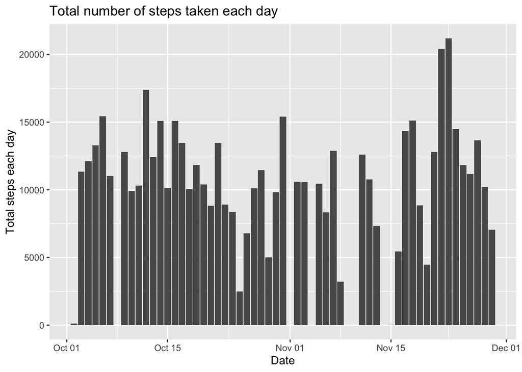

```r
library(ggplot2)
ggplot(totalstep,
       aes(y=totalstep$steps,
           x=totalstep$date))+
  geom_bar(stat="identity") +
  ylab("Total steps each day")+
  xlab("Date")+
  ggtitle("Total number of steps taken each day")
```

## Calculate and report the mean and median of the total number of steps taken per day

## The mean and median of the total number of steps taken per day are 10766.19 and 10765 respectively.

```r
overall.mean.step <- mean(totalstep$steps)
overall.mean.step
```

```
## [1] 10766.19
```

```r
overall.median.step <- median(totalstep$steps)
overall.median.step
```

```
## [1] 10765
```

```r
library(dplyr)
library(tidyr)
mean.step <- data %>%
  select(date,steps) %>%
  group_by(date) %>%
  summarise(mean(steps))%>%
  drop_na()
```

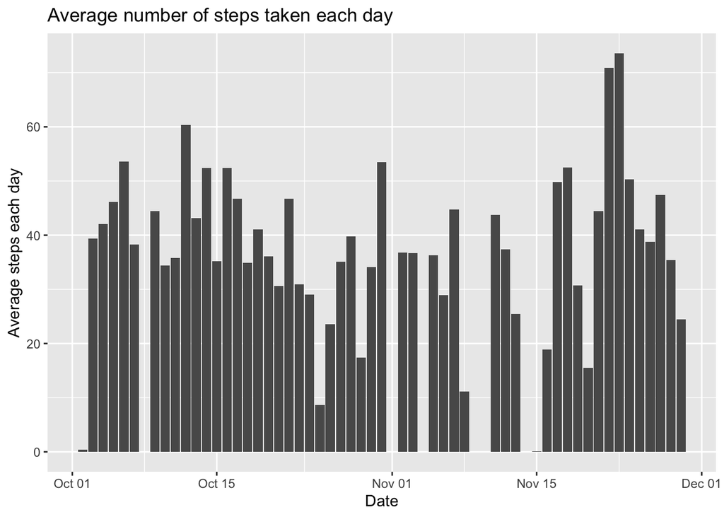

```r
ggplot(mean.step,
       aes(y=mean.step$`mean(steps)`,
           x=mean.step$date))+
  geom_bar(stat="identity") +
  ylab("Average steps each day")+
  xlab("Date")+
  ggtitle("Average number of steps taken each day")
```

```r
media.step <- data %>%
  select(date,steps) %>%
  group_by(date) %>%
  summarise(median(steps))%>%
  drop_na()
```

# Q2: What is the average daily activity pattern?

## Make a time series plot (i.e. type = “l”) of the 5-minute interval (x-axis) and the average number of steps taken, averaged across all days (y-axis)

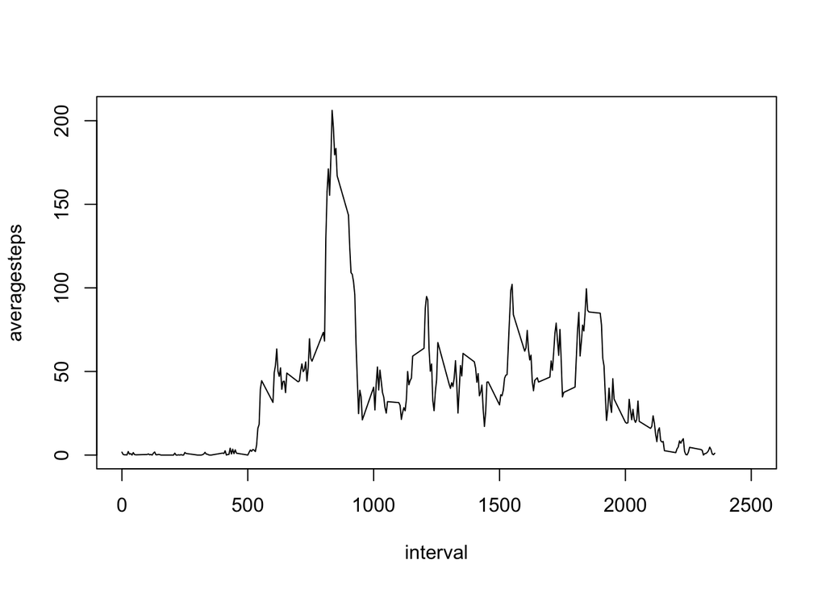

```r
intervalstep <- aggregate(steps ~ interval, data, mean, na.rm = TRUE)
names(intervalstep) <- c("interval", "averagesteps")
plot(averagesteps ~ interval,
     data = intervalstep,
     type = "l",
     xlim=c(0,2500))
```

## Which 5-minute interval, on average across all the days in the dataset, contains the maximum number of steps?

## The maximum number of steps is in the No.835 5-minute interval

```r
intervalstep[which.max(intervalstep$averagesteps), ]$interval
```

```
## [1] 835
```